# Spanish Translation - A/B Testing

A crucial assumption behind an A/B test is that the only difference between test and control has to be the feature we are testing. This implies that test and control user distributions are comparable. If this is true, we can then exactly estimate the impact of the feature change on whichever metric we are testing.

Comparable test and control user distribution means that, for each relevant segment, the relative proportion of users in test and control is similar. That is, if US users are 10% of users in the test group, we expect to also have ~10% of US users in control. If we have 50% of repeat users in test, we should have a similar percentage in control, and so on.  
From a purely statistical standpoint, the above should be true over a large enough number of users. And in A/B testing, we are looking for very small gains, so sample size is large, and, therefore, test and control distributions should be the same.

In practice, it is pretty frequent that test and control distributions are different, invalidating the test results. The number one reason for that is bugs or bias in the randomization algorithm that assigns users to test and control, leading to over/under representation of certain segments. That is, we might have more US users in control, but those users have higher conversion rate, so the difference we see in the metric is not only affected by the feature change that we are testing.

It is therefore extremely important to check that test and control distributions are similar before doing the statistical test. Let’s see how.

## Data

### R

```r
#libraries needed
require(dplyr)
require(rpart)
require(ggplot2)

#read data
user = read.csv("Translation_Test/user_table.csv")
test = read.csv("Translation_Test/test_table.csv")

dim(user)
```

```
[1] 452867      4
```

```r
dim(test)
```

```
[1] 453321      9
```

```r
#let's check that data makes sense

# are there dupes in either dataset?
length(unique(test$user_id)) == length(test$user_id)
```

```
[1] TRUE
```

```r
length(unique(user$user_id)) == length(user$user_id)
```

```
[1] TRUE
```

```r
#everyone in one table also in the other one?
length(user$user_id) - length(test$user_id)
```

```
[1] -454
```

Looks like the user table is busted and we have some user ids missing. It is so few values that we can safely get rid of those with an inner join. Nothing will change. However, separately, we should still try to find out why that happened. There might be some bug somewhere.

```r
# join
data = merge(test, user, by = "user_id")

data$date = as.Date(data$date)
summary(data)
```

```
    user_id             date               source          device       browser_language   ads_channel            browser         conversion
 Min.   :      1   Min.   :2015-11-30   Ads   :181693   Mobile:201551   EN   : 63079     Bing    : 13670   Android_App:154977   Min.   :0.00000
 1st Qu.: 249819   1st Qu.:2015-12-01   Direct: 90738   Web   :251316   ES   :377160     Facebook: 68358   Chrome     :101822   1st Qu.:0.00000
 Median : 500019   Median :2015-12-03   SEO   :180436                   Other: 12628     Google  : 68113   FireFox    : 40721   Median :0.00000
 Mean   : 499945   Mean   :2015-12-02                                                    Other   :  4143   IE         : 61656   Mean   :0.04956
 3rd Qu.: 749543   3rd Qu.:2015-12-04                                                    Yahoo   : 27409   Iphone_App : 46574   3rd Qu.:0.00000
 Max.   :1000000   Max.   :2015-12-04                                                    NA's    :271174   Opera      :  6084   Max.   :1.00000
                                                                                                           Safari     : 41033
      test        sex             age             country
 Min.   :0.0000   F:188382   Min.   :18.00   Mexico   :128484
 1st Qu.:0.0000   M:264485   1st Qu.:22.00   Colombia : 54060
 Median :0.0000              Median :26.00   Spain    : 51782
 Mean   :0.4765              Mean   :27.13   Argentina: 46733
 3rd Qu.:1.0000              3rd Qu.:31.00   Peru     : 33666
 Max.   :1.0000              Max.   :70.00   Venezuela: 32054
                                             (Other)  :106088
```

First question is about checking the test results. But even before that, let’s make sure it is true Spain converts much better than LatAm countries.

```r
data_conversion_country = data %>%
                          group_by(country) %>%
                          # we check the old version
                          summarize( conversion = mean(conversion[test == 0]))%>%
                          arrange (desc(conversion))

data_conversion_country
```

```
# A tibble: 17 x 2
   country     conversion
   <fct>            <dbl>
 1 Spain           0.0797
 2 El Salvador     0.0536
 3 Nicaragua       0.0526
 4 Costa Rica      0.0523
 5 Colombia        0.0521
 6 Honduras        0.0509
 7 Guatemala       0.0506
 8 Venezuela       0.0503
 9 Peru            0.0499
10 Mexico          0.0495
11 Bolivia         0.0494
12 Ecuador         0.0492
13 Paraguay        0.0485
14 Chile           0.0481
15 Panama          0.0468
16 Argentina       0.0151
17 Uruguay         0.0120
```

Yes. Definitely true.

```r
#a simple t-test here should work. We have collected ~0.5MM data and test/control split is ~50/50.

#nothing changed in Spain, so no point in keeping those users
data = subset(data, country != "Spain")
t.test(data$conversion[data$test == 1], data$conversion[data$test == 0])
```

```
    Welch Two Sample t-test

data:  data$conversion[data$test == 1] and data$conversion[data$test == 0]
t = -7.3539, df = 385260, p-value = 1.929e-13
alternative hypothesis: true difference in means is not equal to 0
95 percent confidence interval:
 -0.006181421 -0.003579837
sample estimates:
 mean of x  mean of y
0.04341116 0.04829179
```

Mmh…control users are converting at 4.8% while users in the test just at 4.3%. That’s a 10% drop, which would be dramatic if it were true. The most likely reason for weird A/B test results are:  
1) We didn’t collect enough data  
2) Some bias has been introduced in the experiment so that test/control people are not really random

In data science, whenever results appear too bad or too good to be true, they are not true.

Firstly, let’s plot day by day, to see if these weird results have been constantly happening or they just started happening all of a sudden.

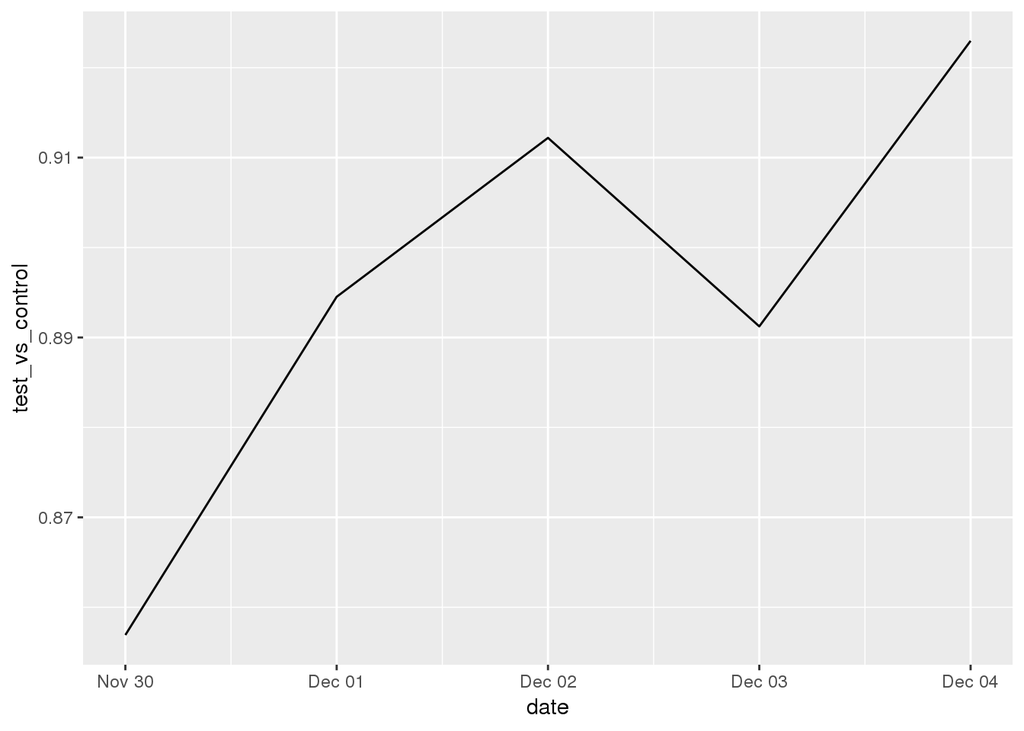

```r
data_test_by_day = data %>%
                   group_by(date) %>%
                   summarize(test_vs_control = mean(conversion[test==1])/
                                               mean(conversion[test==0])
                            )

qplot(date, test_vs_control, data= data_test_by_day, geom = "line")
```

From the plot, we notice a couple of things:

1. Test has constantly been worse than control and there is relatively little variance across days. That probably means that we do have enough data, but there was some bias in the experiment set up
2. As a side note, we just ran it for 5 days. We should always run the test for at least 1 full week to capture weekly patterns, 2 weeks would be much better

Time to find out the bias! Likely, there is some segment of users more likely to end up in test or in control. This segment had a significantly above/below conversion rate and this affected the overall results.

### Python

```python
import pandas
pandas.set_option('display.max_columns', 20)
pandas.set_option('display.width', 350)

#read data
user = pandas.read_csv("Translation_Test/user_table.csv")
test = pandas.read_csv("Translation_Test/test_table.csv")

print(user.shape)
```

```
(452867, 4)
```

```python
print(test.shape)
```

```
(453321, 9)
```

```python
#let's check that data makes sense

print(test['user_id'].nunique()==len(test['user_id']))
```

```
True
```

```python
print(user['user_id'].nunique()==len(user['user_id']))
```

```
True
```

```python
print(len(user['user_id']) - len(test['user_id']))
```

```
-454
```

Looks like the user table is busted and we have some user ids missing. It is so few values that we can safely get rid of those with an inner join. Nothing will change. However, separately, we should still try to find out why that happened. There might be some bug somewhere.

```python
# join
data = test.merge(user, on=['user_id'])

#make it a date
data["date"]   = pandas.to_datetime(data["date"])
print(data.describe(include="all"))
```

```
               user_id                 date  source  device browser_language ads_channel      browser     conversion           test     sex            age country
count    452867.000000               452867  452867  452867           452867      181693       452867  452867.000000  452867.000000  452867  452867.000000  452867
unique             NaN                    5       3       2                3           5            7            NaN            NaN       2            NaN      17
top                NaN  2015-12-04 00:00:00     Ads     Web               ES    Facebook  Android_App            NaN            NaN       M            NaN  Mexico
freq               NaN               141024  181693  251316           377160       68358       154977            NaN            NaN  264485            NaN  128484
first              NaN  2015-11-30 00:00:00     NaN     NaN              NaN         NaN          NaN            NaN            NaN     NaN            NaN     NaN
last               NaN  2015-12-04 00:00:00     NaN     NaN              NaN         NaN          NaN            NaN            NaN     NaN            NaN     NaN
mean     499944.805166                  NaN     NaN     NaN              NaN         NaN          NaN       0.049560       0.476462     NaN      27.130740     NaN
std      288676.264784                  NaN     NaN     NaN              NaN         NaN          NaN       0.217034       0.499446     NaN       6.776678     NaN
min           1.000000                  NaN     NaN     NaN              NaN         NaN          NaN       0.000000       0.000000     NaN      18.000000     NaN
25%      249819.000000                  NaN     NaN     NaN              NaN         NaN          NaN       0.000000       0.000000     NaN      22.000000     NaN
50%      500019.000000                  NaN     NaN     NaN              NaN         NaN          NaN       0.000000       0.000000     NaN      26.000000     NaN
75%      749543.000000                  NaN     NaN     NaN              NaN         NaN          NaN       0.000000       1.000000     NaN      31.000000     NaN
max     1000000.000000                  NaN     NaN     NaN              NaN         NaN          NaN       1.000000       1.000000     NaN      70.000000     NaN
```

First question is about checking the test results. But even before that, let’s make sure it is true Spain converts much better than LatAm countries.

```python
country_conversion = data.query('test == 0').groupby('country')['conversion'].mean()

print(country_conversion.sort_values(ascending=False))
```

```
country
Spain          0.079719
El Salvador    0.053554
Nicaragua      0.052647
Costa Rica     0.052256
Colombia       0.052089
Honduras       0.050906
Guatemala      0.050643
Venezuela      0.050344
Peru           0.049914
Mexico         0.049495
Bolivia        0.049369
Ecuador        0.049154
Paraguay       0.048493
Chile          0.048107
Panama         0.046796
Argentina      0.015071
Uruguay        0.012048
Name: conversion, dtype: float64
```

Yes. Definitely true.

```python
#a simple t-test here should work. We have collected ~0.5MM data and test/control split is ~50/50.
from scipy import stats

#nothing changed in Spain, so no point in keeping those users
data = data.query('country != "Spain"')

#t-test of test vs control for our target metric
test = stats.ttest_ind(data[data['test'] == 1]['conversion'],
                       data[data['test'] == 0]['conversion'],
                       equal_var=False
                       )

print(data.groupby('test')['conversion'].mean())
```

```
test
0    0.048292
1    0.043411
Name: conversion, dtype: float64
```

```python
print(test.statistic)
```

```
-7.353895203080277
```

```python
print(test.pvalue)
```

```
1.9289178577799033e-13
```

Mmh…control users are converting at 4.8% while users in the test just at 4.3%. That’s a 10% drop, which would be dramatic if it were true. The most likely reason for weird A/B test results are:  
1) We didn’t collect enough data  
2) Some bias has been introduced in the experiment so that test/control people are not really random

In data science, whenever results appear too bad or too good to be true, they are not true.

Firstly, let’s plot day by day, to see if these weird results have been constantly happening or they just started happening all of a sudden.

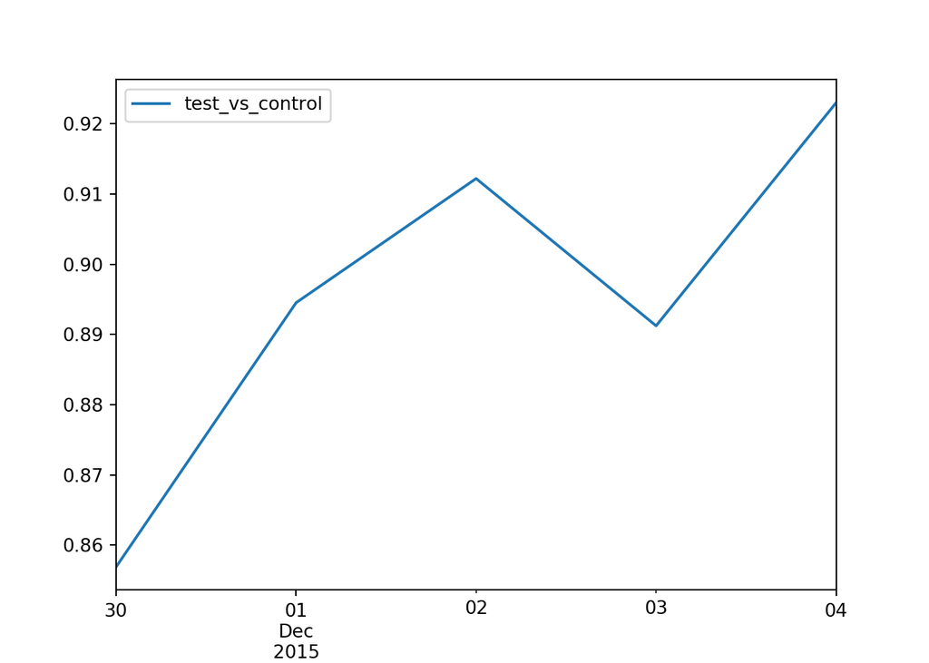

```python
import matplotlib.pyplot as plt

#compare test and control conversion rate by day and plot it
data_test_by_day = data.groupby("date")["conversion"].agg({
"test_vs_control": lambda x: x[data["test"]==1].mean()/x[data["test"]==0].mean()
}).plot()
plt.show()
```

From the plot, we notice a couple of things:

1. Test has constantly been worse than control and there is relatively little variance across days. That probably means that we do have enough data, but there was some bias in the experiment set up
2. As a side note, we just ran it for 5 days. We should always run the test for at least 1 full week to capture weekly patterns, 2 weeks would be much better

Time to find out the bias! Likely, there is some segment of users more likely to end up in test or in control. This segment had a significantly above/below conversion rate and this affected the overall results.

## Check A/B Test Randomization

### R

Checking that randomization worked well simply means making sure that all variables have the same distribution in test and control. So, taking for instance the first variable, source, it would mean checking that proportion of users coming from ads, SEO, and direct is the same.

This can easily be done the following way:

```r
#let's group by source and estimate relative frequencies
data%>%
  group_by(source) %>%
  summarize(
   test_relative_frequency = length(source[test==1])/nrow(data[data$test==1,]),
   control_relative_frequency = length(source[test==0])/nrow(data[data$test==0,])
  )
```

```
# A tibble: 3 x 3
  source test_relative_frequency control_relative_frequency
  <fct>                    <dbl>                      <dbl>
1 Ads                      0.401                      0.401
2 Direct                   0.200                      0.201
3 SEO                      0.400                      0.398
```

As we can see, relative frequency of source for different segments is the same. That is, we have basically the same proportion of users coming from Ads, Direct, and SEO in both test and control.

We could potentially keep checking all the variables like this. But it would be extremely time consuming (and boring), especially when you start considering numerical variables and categorical variables with many levels.

So we turn this into a machine learning problem and let an algorithm do the boring work for us. The approach is:

1. Get rid of the conversion variable for now. We don’t care about it here. We are just checking if the two user distributions are the same. This is before we check conversion rate for the groups
2. Use the variable test as our label. Try to build a model that manages to separate the users whose test value is 0 vs those whose test value is 1. If randomization worked well, this will be impossible because the two groups are exactly the same. If all variable relative frequencies were the same as for source, no model would be able to separate test == 1 vs test == 0. If randomization did not work well, the model will manage to use a given variable to separate the two groups.
3. As a model, pick a decision tree. This will allow you to clearly see which variable (if any) is used for the split. That’s where randomization failed.

```r
library(rpart)
library(rpart.plot)

#prepare the data set to check if randomization worked well

#mke it into a classification problem
data$test = as.factor(data$test)

#Build the decision tree
tree = rpart (test ~ .,
              #get rid of conversion, not needed here
              subset(data, select=-conversion),
              #make classes balanced, easier to understand the output.
              parms = list(prior = c(0.5, 0.5))
              )

tree
```

```
n= 401085

node), split, n, loss, yval, (yprob)
      * denotes terminal node

1) root 401085 200542.50 1 (0.5000000 0.5000000)
  2) country=Bolivia,Chile,Colombia,Costa Rica,Ecuador,El Salvador,Guatemala,Honduras,Mexico,Nicaragua,Panama,Paraguay,Peru,Venezuela 350218 162347.50 0 (0.5391991 0.4608009) *
  3) country=Argentina,Uruguay 50867  10574.12 1 (0.2168199 0.7831801) *
```

So we can see that test and control are not the same! Users from Argentina and Uruguay are way more likely to be in test than control (~78% vs 22%, respectively).

Let’s double check this. Let’s check proportion of Argentinian and Uruguayan users in control vs test.

```r
#dummy variable just for Argentinia and Uruguay users
data$is_argentina = ifelse(data$country == "Argentina",1, 0)
data$is_uruguay =   ifelse(data$country == "Uruguay",1, 0)

data%>%
  group_by(test) %>% #let's check for both test and control
  summarize(
             Argentina_relative_frequency = mean(is_argentina),
             Uruguay_relative_frequency = mean(is_uruguay)
  )
```

```
# A tibble: 2 x 3
  test  Argentina_relative_frequency Uruguay_relative_frequency
  <fct>                        <dbl>                      <dbl>
1 0                           0.0505                    0.00224
2 1                           0.173                     0.0172
```

Our tree was right! In test, 17% of users are from Argentina, but in control, only 5% of users are from Argentina. Uruguay is even more extreme: test has 1.7% of users from Uruguay and control has basically no Uruguayan users (0.2%).

And this is a big problem because that means we are not comparing anymore apples to apples in our A/B test. The difference we might see in conversion rate might very well depend on the fact that users between the two groups are different.

Let’s check it in practice.

```r
#this is the test results using the orginal dataset
original_data = t.test(data$conversion[data$test==1], data$conversion[data$test==0])

#this is after removing Argentina and Uruguay
data_no_AR_UR = t.test(data$conversion[data$test==1 &
                                       !data$country%in%c("Argentina", "Uruguay")
                                       ],
                       data$conversion[data$test==0 &
                                       !data$country%in%c("Argentina", "Uruguay")
                                       ]
                       )

data.frame(data_type = c("Full", "Removed_Argentina_Uruguay"),
           p_value = c(original_data$p.value, data_no_AR_UR$p.value),
           t_statistic = c(original_data$statistic, data_no_AR_UR$statistic)
)
```

```
                  data_type      p_value t_statistic
1                      Full 1.928918e-13  -7.3538952
2 Removed_Argentina_Uruguay 7.200849e-01   0.3583456
```

Huge difference! The biased test where some countries are over/under represented is statistically significant with negative t statistics. So test is worse than control! After removing those two countries, we get non-significant results.

We can also get to the same conclusion by checking how each country is doing taken by itself:

```r
data_test_country = data %>%
                    group_by(country) %>%
                    summarize( p_value = t.test( conversion[test==1],
                                                 conversion[test==0]
                                                )$p.value,
                               conversion_test = t.test( conversion[test==1],
                                                         conversion[test==0]
                                                       )$estimate[1],
                               conversion_control = t.test( conversion[test==1],
                                                            conversion[test==0]
                                                          )$estimate[2]
                             ) %>%
                    arrange (p_value)
data_test_country
```

```
# A tibble: 16 x 4
   country     p_value conversion_test conversion_control
   <fct>         <dbl>           <dbl>              <dbl>
 1 Mexico        0.166          0.0512             0.0495
 2 El Salvador   0.248          0.0479             0.0536
 3 Chile         0.303          0.0513             0.0481
 4 Argentina     0.335          0.0137             0.0151
 5 Colombia      0.424          0.0506             0.0521
 6 Honduras      0.471          0.0475             0.0509
 7 Guatemala     0.572          0.0486             0.0506
 8 Venezuela     0.574          0.0490             0.0503
 9 Costa Rica    0.688          0.0547             0.0523
10 Panama        0.705          0.0494             0.0468
11 Bolivia       0.719          0.0479             0.0494
12 Peru          0.772          0.0506             0.0499
13 Nicaragua     0.780          0.0542             0.0526
14 Uruguay       0.880          0.0129             0.0120
15 Paraguay      0.884          0.0492             0.0485
16 Ecuador       0.962          0.0490             0.0492
```

After we control for country, the test clearly appears non significant. Not a great success given that the goal was to improve conversion rate, but at least we know that a localized translation didn’t make things worse!  
At this point, you have two options:

1. Acknowledge that there was a bug, go talk to the software engineer in charge of randomization, figure out what went wrong, fix it and re-run the test. Note that when you find a bug, it might be a sign that more things are messed up, not just the one you found. So when you find a bug, always try to get to the bottom of it
2. If you do find out that everything was fine, but for some reason there was only a problem with those two countries, you can potentially adjust the weights for those two segments so that relative frequencies become the same and then re-check the test results

[Click here for a full course in product data science](https://course.datamasked.com)

### Python

Checking that randomization worked well simply means making sure that all variables have the same distribution in test and control. So, taking for instance the first variable, source, it would mean checking that proportion of users coming from ads, SEO, and direct is the same.

This can easily be done the following way:

```python
#let's group by source and estimate relative frequencies
data_grouped_source = data.groupby("source")["test"].agg({
"frequency_test_0": lambda x: len(x[x==0]),
"frequency_test_1": lambda x: len(x[x==1])
})

#get relative frequencies
print(data_grouped_source/data_grouped_source.sum())
```

```
        frequency_test_0  frequency_test_1
source
Ads             0.401228          0.400641
Direct          0.200949          0.199500
SEO             0.397823          0.399858
```

As we can see, relative frequency of source for different segments is the same. That is, we have basically the same proportion of users coming from Ads, Direct, and SEO in both test and control.

We could potentially keep checking all the variables like this. But it would be extremely time consuming (and boring), especially when you start considering numerical variables and categorical variables with many levels.

So we turn this into a machine learning problem and let an algorithm do the boring work for us. The approach is:

1. Get rid of the conversion variable for now. We don’t care about it here. We are just checking if the two user distributions are the same. This is before we check conversion rate for the groups
2. Use the variable test as our label. Try to build a model that manages to separate the users whose test value is 0 vs those whose test value is 1. If randomization worked well, this will be impossible because the two groups are exactly the same. If all variable relative frequencies were the same as for source, no model would be able to separate test == 1 vs test == 0. If randomization did not work well, the model will manage to use a given variable to separate the two groups.
3. As a model, pick a decision tree. This will allow you to clearly see which variable (if any) is used for the split. That’s where randomization failed.

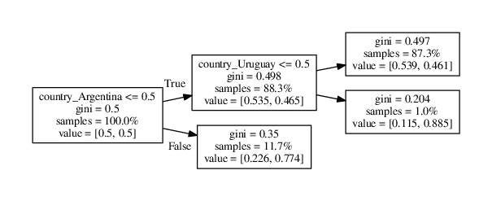

```python
import graphviz
from sklearn.tree import DecisionTreeClassifier
from sklearn.tree import export_graphviz
from graphviz import Source

#make date as string, so few dates that makes sense to have them as few dummy values
data['date'] = data['date'].apply(str)

#make dummy vars. Don't drop one level here, keep them all. You don't want to risk dropping the one level that actually creates problems with the randomization
data_dummy = pandas.get_dummies(data)
#model features, test is the label and conversion is not needed
train_cols = data_dummy.drop(['test', 'conversion'], axis=1)

tree=DecisionTreeClassifier(
    #change weights. Our data set is now perfectly balanced. It makes easier to understand the tree output
    class_weight="balanced",
    #only split if if it's worthwhile. The default value of 0 means always split no matter what if you can increase overall performance, which creates tons of noisy and irrelevant splits
    min_impurity_decrease = 0.001
    )
tree.fit(train_cols,data_dummy['test'])

export_graphviz(tree, out_file="tree_test.dot", feature_names=train_cols.columns, proportion=True, rotate=True)
with open("tree_test.dot") as f:
    dot_graph = f.read()

s = Source.from_file("tree_test.dot")
s.view()
```

So we can see that test and control are not the same! Users from Argentina and Uruguay are way more likely to be in test than control. When country_Argentina is 1, the tree shows that users in control are ~23% and in test 77%. For Uruguay, the proportions are even more extreme: 11% in control and 89% in test! Not good!

Let’s double check this. Let’s check proportion of Argentinian and Uruguayan users in control vs test.

```python
print(data_dummy.groupby("test")[["country_Argentina", "country_Uruguay"]].mean())
```

```
      country_Argentina  country_Uruguay
test
0              0.050488         0.002239
1              0.173223         0.017236
```

Our tree was right! In test, 17% of users are from Argentina, but in control only 5% of users are from Argentina. Uruguay is even more extreme: test has 1.7% of users from Uruguay and control has just 0.2% of Uruguayan users.

And this is a big problem because that means we are not comparing anymore apples to apples in our A/B test. The difference we might see in conversion rate might very well depend on the fact that users between the two groups are different.

Let’s check it in practice:

```python
#this is the test results using the orginal dataset
original_data = stats.ttest_ind(data_dummy[data['test'] == 1]['conversion'],
                                data_dummy[data['test'] == 0]['conversion'],
                                equal_var=False)

#this is after removing Argentina and Uruguay
data_no_AR_UR = stats.ttest_ind(data_dummy[(data['test'] == 1) &
                                           (data_dummy['country_Argentina'] ==  0) &
                                           (data_dummy['country_Uruguay'] ==  0)
                                           ]['conversion'],
                                data_dummy[(data['test'] == 0) &
                                           (data_dummy['country_Argentina'] ==  0) &
                                           (data_dummy['country_Uruguay'] ==  0)
                                           ]['conversion'],
                                equal_var=False)

print(
pandas.DataFrame({"data_type" : ["Full", "Removed_Argentina_Uruguay"],
                  "p_value" : [original_data.pvalue, data_no_AR_UR.pvalue],
                  "t_statistic" : [original_data.statistic, data_no_AR_UR.statistic]
                 })
)
```

```
                   data_type       p_value  t_statistic
0                       Full  1.928918e-13    -7.353895
1  Removed_Argentina_Uruguay  7.200849e-01     0.358346
```

Huge difference! The biased test where some countries are over/under represented is statistically significant with negative t statistics. So test is worse than control! After removing those two countries, we get non-significant results.

We can also get to the same conclusion by checking how each country is doing taken by itself:

```python
data_test_country = data.groupby('country')['conversion'].agg({
                   "p_value": lambda x: stats.ttest_ind(x[data["test"]==1],
                                                        x[data["test"]==0],
                                                        equal_var=False
                                                        ).pvalue,
                   "conversion_test": lambda x: x[data["test"]==1].mean(),
                   "conversion_control": lambda x: x[data["test"]==0].mean()
                   }).reindex(['p_value','conversion_test','conversion_control'],
                                   axis=1
                                 )
print(data_test_country.sort_values(by=['p_value']))
```

```
              p_value  conversion_test  conversion_control
country
Mexico       0.165544         0.051186            0.049495
El Salvador  0.248127         0.047947            0.053554
Chile        0.302848         0.051295            0.048107
Argentina    0.335147         0.013725            0.015071
Colombia     0.423719         0.050571            0.052089
Honduras     0.471463         0.047540            0.050906
Guatemala    0.572107         0.048647            0.050643
Venezuela    0.573702         0.048978            0.050344
Costa Rica   0.687876         0.054738            0.052256
Panama       0.705327         0.049370            0.046796
Bolivia      0.718885         0.047901            0.049369
Peru         0.771953         0.050604            0.049914
Nicaragua    0.780400         0.054177            0.052647
Uruguay      0.879764         0.012907            0.012048
Paraguay     0.883697         0.049229            0.048493
Ecuador      0.961512         0.048988            0.049154
```

After we control for country, the test clearly appears non significant. Not a great success given that the goal was to improve conversion rate, but at least we know that a localized translation didn’t make things worse!

At this point, you have two options:

1. Acknowledge that there was a bug, go talk to the software engineer in charge of randomization, figure out what went wrong, fix it and re-run the test. Note that when you find a bug, it might be a sign that more things are messed up, not just the one you found. So when you find a bug, always try to get to the bottom of it
2. If you do find out that everything else was fine, but for some reason there was only a problem with those two countries, you can potentially adjust the weights for those two segments so that relative frequencies become the same and then re-check the test results

[Click here for a full course in product data science](https://course.datamasked.com)